# QC_check_filtering

```python
! python --version
```

```
Python 3.11.9
```

```python
import numpy as np
import pandas as pd

import matplotlib.pyplot as plt
import seaborn as sns

import scanpy as sc

import scipy.sparse

import anndata as an
import scanorama

from pathlib import Path

import squidpy as sq

import os

from matplotlib import cm, colors
from matplotlib.lines import Line2D

sc.logging.print_versions()
```

[output not shown]

[output cut: 107 more lines]

[output not shown]

```python
import warnings
warnings.simplefilter("ignore")
```

```python
custom_palette = [ "#a70e62", "#e10e3c", "#f47140", "#f0b932", "#ffd95a", "#c2ed51", "#8ed73d", "#489c73", "#1a8d83",
                  "#4915be", "#2357d5", "#fed2ff", "#6ecad5", "#BD08F9", '#886fc2', "#e170c0", "#FF33CC", "#e4a9e8"]

# Read the list of genes, 200 spike genes subset
genes_to_include_file =  "subset_spikegenes_list.txt"

with open(genes_to_include_file, "r") as file:
    genes_to_include = [line.strip() for line in file]
```

### import in data sets, trim down to area of interest, calculate QC metrics

VGN1e1 = late double ridge, VRT-A2a (P1 WT)

VGN1e9 = late double ridge, VRT-A2b (P1 Pol)

VGN1b6 = lemma primorida, VRT-A2a (P1 WT)

VGN1b8 = lemma primorida, VRT-A2b (P1 Pol)

VGN1a6 = terminal spikelet, VRT-A2a (P1 WT)

VGN1a4 = terminal spikelet, VRT-A2b (P1 Pol)

VGN1c2 = carpel extension round, VRT-A2a (P1 WT)

VGN1c3 = carpel extension round, VRT-A2b (P1 Pol)

See vignette: https://squidpy.readthedocs.io/en/stable/notebooks/tutorials/tutorial_vizgen_mouse_liver.html

```python
import warnings
warnings.simplefilter("ignore")


#VGN1a6
adata_VGN1a6 = sq.read.vizgen(
    path="cell_segmentation/VGN1a_region6_output/",
    counts_file="cell_by_gene.csv",
    meta_file="cell_metadata.csv",
    transformation_file="micron_to_mosaic_pixel_transform.csv"
)
# filters to 200 genes
adata_VGN1a6 = adata_VGN1a6[:, adata_VGN1a6.var_names.isin(genes_to_include)]

#VGN1a4
adata_VGN1a4 = sq.read.vizgen(
    path="cell_segmentation/VGN1a_region4_output/",
    counts_file="cell_by_gene.csv",
    meta_file="cell_metadata.csv",
    transformation_file="micron_to_mosaic_pixel_transform.csv"
)
# filters to 200 genes
adata_VGN1a4 = adata_VGN1a4[:, adata_VGN1a4.var_names.isin(genes_to_include)]

#VGN1b6
adata_VGN1b6 = sq.read.vizgen(
    path="cell_segmentation/VGN1b_region6_output/",
    counts_file="cell_by_gene.csv",
    meta_file="cell_metadata.csv",
    transformation_file="micron_to_mosaic_pixel_transform.csv"
)

#set the local min & max of dataframe
region_min_x = 5001.371569839002
region_min_y = 3989.694988634645
region_max_x = 5829.68
region_max_y = 6225.69510252610

# Filter observations based on the defined region
region_mask = (
    (adata_VGN1b6.obs['min_x'] >= region_min_x) &
    (adata_VGN1b6.obs['min_y'] >= region_min_y) &
    (adata_VGN1b6.obs['max_x'] <= region_max_x) &
    (adata_VGN1b6.obs['max_y'] <= region_max_y)
)
adata_VGN1b6 = adata_VGN1b6[region_mask]
# filters to 200 genes
adata_VGN1b6 = adata_VGN1b6[:, adata_VGN1b6.var_names.isin(genes_to_include)]

#VGN1b8
adata_VGN1b8 = sq.read.vizgen(
    path="cell_segmentation/VGN1b_region8_output/",
    counts_file="cell_by_gene.csv",
    meta_file="cell_metadata.csv",
    transformation_file="micron_to_mosaic_pixel_transform.csv"
)

# Define the coordinates of the region you are interested in
region_min_x = 873.0
region_min_y = 6207.0
region_max_x = 1855.0
region_max_y = 7558.0

# Filter observations based on the defined region
region_mask = (
    (adata_VGN1b8.obs['min_x'] >= region_min_x) &
    (adata_VGN1b8.obs['min_y'] >= region_min_y) &
    (adata_VGN1b8.obs['max_x'] <= region_max_x) &
    (adata_VGN1b8.obs['max_y'] <= region_max_y)
)
adata_VGN1b8 = adata_VGN1b8[region_mask]
# filters to 200 genes
adata_VGN1b8 = adata_VGN1b8[:, adata_VGN1b8.var_names.isin(genes_to_include)]

#VGN1c2
adata_VGN1c2 = sq.read.vizgen(
    path="cell_segmentation/VGN1c_region2_output/",
    counts_file="cell_by_gene.csv",
    meta_file="cell_metadata.csv",
    transformation_file="micron_to_mosaic_pixel_transform.csv"
)

# filters to 200 genes
adata_VGN1c2 = adata_VGN1c2[:, adata_VGN1c2.var_names.isin(genes_to_include)]

#VGN1c3
adata_VGN1c3 = sq.read.vizgen(
    path="cell_segmentation/VGN1c_region3_output/",
    counts_file="cell_by_gene.csv",
    meta_file="cell_metadata.csv",
    transformation_file="micron_to_mosaic_pixel_transform.csv"
)

# filters to 200 genes
adata_VGN1c3 = adata_VGN1c3[:, adata_VGN1c3.var_names.isin(genes_to_include)]

#VGN1e1
adata_VGN1e1 = sq.read.vizgen(
    path="cell_segmentation/VGN1e_region1_output/",
    counts_file="cell_by_gene.csv",
    meta_file="cell_metadata.csv",
    transformation_file="micron_to_mosaic_pixel_transform.csv"
)
# Define the coordinates of the region you are interested in
region_min_x = 3284.0
region_min_y = 6279.0
region_max_x = 4481.0
region_max_y = 7870.0

# Filter observations based on the defined region
region_mask = (
    (adata_VGN1e1.obs['min_x'] >= region_min_x) &
    (adata_VGN1e1.obs['min_y'] >= region_min_y) &
    (adata_VGN1e1.obs['max_x'] <= region_max_x) &
    (adata_VGN1e1.obs['max_y'] <= region_max_y)
)
adata_VGN1e1 = adata_VGN1e1[region_mask]
# filters to 200 genes
adata_VGN1e1 = adata_VGN1e1[:, adata_VGN1e1.var_names.isin(genes_to_include)]

#VGN1e9
adata_VGN1e9 = sq.read.vizgen(
    path="cell_segmentation/VGN1e_region9_output/",
    counts_file="cell_by_gene.csv",
    meta_file="cell_metadata.csv",
    transformation_file="micron_to_mosaic_pixel_transform.csv"
)

region_min_x = 6403.0
region_min_y = 7843.0
region_max_x = 7400.0
region_max_y = 9614.0

# Filter observations based on the defined region
region_mask = (
    (adata_VGN1e9.obs['min_x'] >= region_min_x) &
    (adata_VGN1e9.obs['min_y'] >= region_min_y) &
    (adata_VGN1e9.obs['max_x'] <= region_max_x) &
    (adata_VGN1e9.obs['max_y'] <= region_max_y)
)
adata_VGN1e9 = adata_VGN1e9[region_mask]
# filter to 200 genes
adata_VGN1e9 = adata_VGN1e9[:, adata_VGN1e9.var_names.isin(genes_to_include)]


adata_VGN1a6.var_names_make_unique()
adata_VGN1a4.var_names_make_unique()
adata_VGN1b6.var_names_make_unique()
adata_VGN1b8.var_names_make_unique()
adata_VGN1c2.var_names_make_unique()
adata_VGN1c3.var_names_make_unique()
adata_VGN1e1.var_names_make_unique()
adata_VGN1e9.var_names_make_unique()
#calculate the QC for each sample, look at the top variable genes
sc.pp.calculate_qc_metrics(adata_VGN1a6, percent_top=(50, 100, 150), inplace=True)
sc.pp.calculate_qc_metrics(adata_VGN1a4, percent_top=(50, 100, 150), inplace=True)
sc.pp.calculate_qc_metrics(adata_VGN1b6, percent_top=(50, 100, 150),inplace=True)
sc.pp.calculate_qc_metrics(adata_VGN1b8, percent_top=(50, 100, 150),inplace=True)
sc.pp.calculate_qc_metrics(adata_VGN1c2, percent_top=(50, 100, 150),inplace=True)
sc.pp.calculate_qc_metrics(adata_VGN1c3, percent_top=(50, 100, 150),inplace=True)
sc.pp.calculate_qc_metrics(adata_VGN1e1, percent_top=(50, 100, 150),inplace=True)
sc.pp.calculate_qc_metrics(adata_VGN1e9, percent_top=(50, 100, 150),inplace=True)
```

# Plot quality metrics before and after filtering low quality cells

"volume". The volume of cells “n_genes_by_counts”. The number of genes with at least 1 count in a cell. Calculated for all cells. "total counts" Sum of counts for a gene.

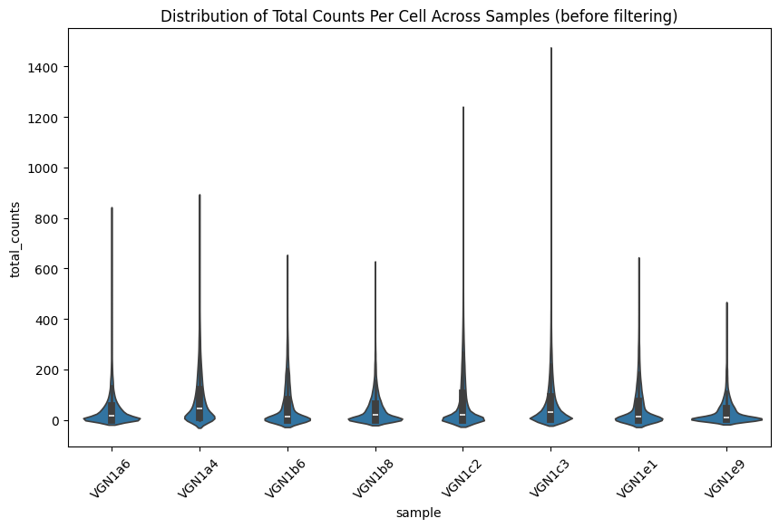

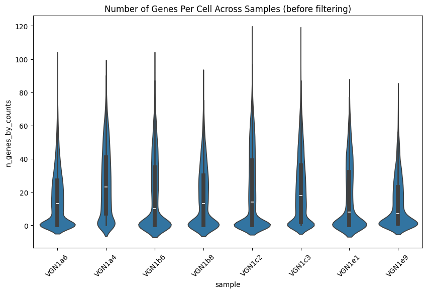

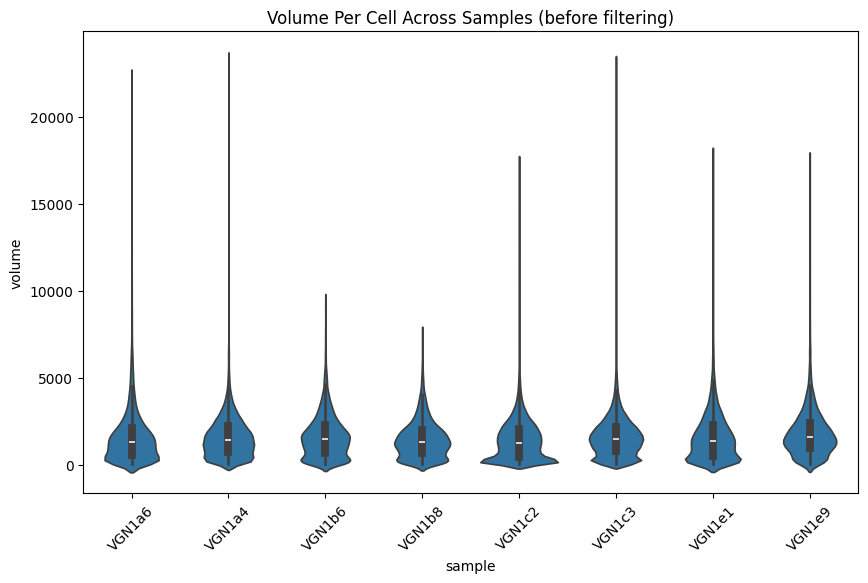

```python
# Create a list of AnnData objects and their corresponding sample names
adata_list = [
    (adata_VGN1a6, "VGN1a6"),
    (adata_VGN1a4, "VGN1a4"),
    (adata_VGN1b6, "VGN1b6"),
    (adata_VGN1b8, "VGN1b8"),
    (adata_VGN1c2, "VGN1c2"),
    (adata_VGN1c3, "VGN1c3"),
    (adata_VGN1e1, "VGN1e1"),
    (adata_VGN1e9, "VGN1e9")
]

# Initialize an empty list to store DataFrames
df_list = []

# Loop through the AnnData objects and create a combined DataFrame
for adata, sample_name in adata_list:
    # Extract the 'total_counts' and 'n_genes_by_counts' metrics from .obs
    df = adata.obs[['total_counts', 'n_genes_by_counts', 'volume']].copy()
    # Add a column for the sample name
    df['sample'] = sample_name
    # Append the DataFrame to the list
    df_list.append(df)

# Concatenate all DataFrames into a single DataFrame
summarystats_beforefiltering_df = pd.concat(df_list)

# Create a violin plot for the total counts
plt.figure(figsize=(10, 6))
sns.violinplot(x='sample', y='total_counts', data=summarystats_beforefiltering_df)
plt.xticks(rotation=45)
plt.title('Distribution of Total Counts Per Cell Across Samples (before filtering)')
plt.show()

# Create a violin plot for the total counts
plt.figure(figsize=(10, 6))
sns.violinplot(x='sample', y='n_genes_by_counts', data=summarystats_beforefiltering_df)
plt.xticks(rotation=45)
plt.title('Number of Genes Per Cell Across Samples (before filtering)')
plt.show()

# Create a violin plot for the total counts
plt.figure(figsize=(10, 6))
sns.violinplot(x='sample', y='volume', data=summarystats_beforefiltering_df)
plt.xticks(rotation=45)
plt.title('Volume Per Cell Across Samples (before filtering)')
plt.show()
```

## Now we filter by minimum counts per cell, as well as cell volume

```python
#for each sample, filter cells so if there are less than 25 counts in the cell, it gets filtered out from dataset
sc.pp.filter_cells(adata_VGN1a6, min_counts=25)
sc.pp.filter_cells(adata_VGN1a4, min_counts=25)
sc.pp.filter_cells(adata_VGN1b6, min_counts=25)
sc.pp.filter_cells(adata_VGN1b8, min_counts=25)
sc.pp.filter_cells(adata_VGN1c2, min_counts=25)
sc.pp.filter_cells(adata_VGN1c3, min_counts=25)
sc.pp.filter_cells(adata_VGN1e1, min_counts=25)
sc.pp.filter_cells(adata_VGN1e9, min_counts=25)

#Filter cells out by cell volume
# Filter adata_VGN1a6
adata_VGN1a6 = adata_VGN1a6[adata_VGN1a6.obs['volume'] > 500]
adata_VGN1a6 = adata_VGN1a6[adata_VGN1a6.obs['volume'] < 10000]
# Filter adata_VGN1a4
adata_VGN1a4 = adata_VGN1a4[adata_VGN1a4.obs['volume'] > 500]
adata_VGN1a4 = adata_VGN1a4[adata_VGN1a4.obs['volume'] < 10000]

# Filter adata_VGN1b6
adata_VGN1b6 = adata_VGN1b6[adata_VGN1b6.obs['volume'] > 500]
adata_VGN1b6 = adata_VGN1b6[adata_VGN1b6.obs['volume'] < 10000]
# Filter adata_VGN1b8
adata_VGN1b8 = adata_VGN1b8[adata_VGN1b8.obs['volume'] > 500]
adata_VGN1b8 = adata_VGN1b8[adata_VGN1b8.obs['volume'] < 10000]

# Filter adata_VGN1e1
adata_VGN1e1 = adata_VGN1e1[adata_VGN1e1.obs['volume'] > 500]
adata_VGN1e1 = adata_VGN1e1[adata_VGN1e1.obs['volume'] < 10000]
# Filter adata_VGN1e9
adata_VGN1e9 = adata_VGN1e9[adata_VGN1e9.obs['volume'] > 500]
adata_VGN1e9 = adata_VGN1e9[adata_VGN1e9.obs['volume'] < 10000]

# Filter adata_VGN1c2
adata_VGN1c2 = adata_VGN1c2[adata_VGN1c2.obs['volume'] > 500]
adata_VGN1c2 = adata_VGN1c2[adata_VGN1c2.obs['volume'] < 10000]
# Filter adata_VGN1c3
adata_VGN1c3 = adata_VGN1c3[adata_VGN1c3.obs['volume'] > 500]
adata_VGN1c3 = adata_VGN1c3[adata_VGN1c3.obs['volume'] < 10000]
```

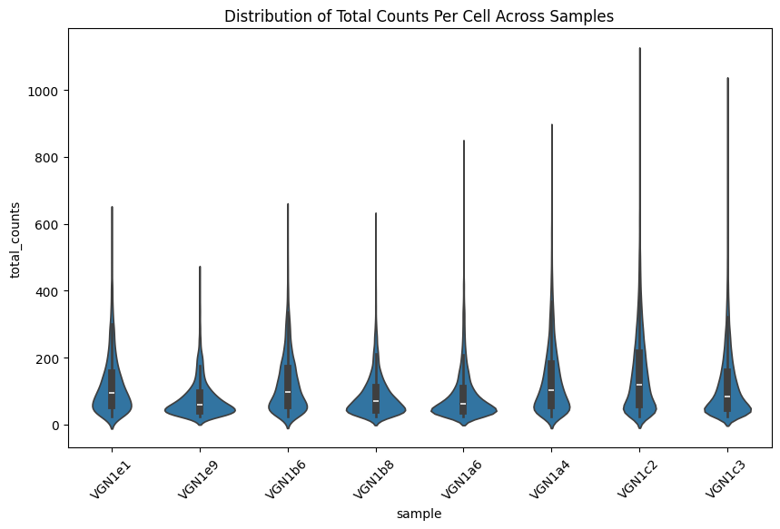

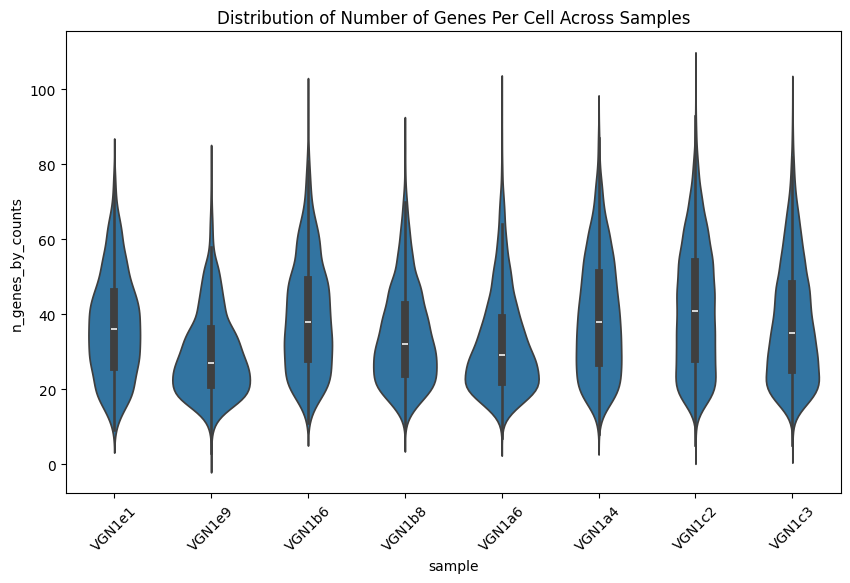

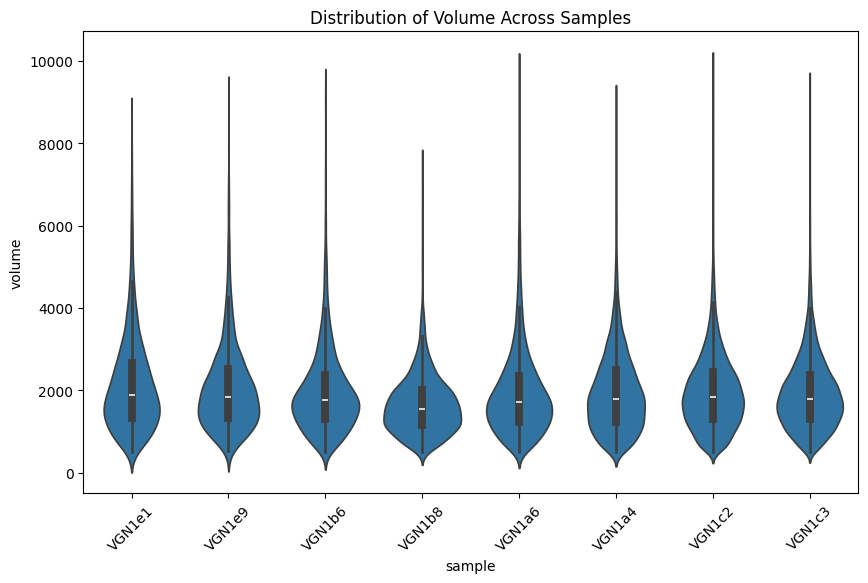

```python
# Create a list of AnnData objects and their corresponding sample names
adata_list = [
    (adata_VGN1a6, "VGN1a6"),
    (adata_VGN1a4, "VGN1a4"),
    (adata_VGN1b6, "VGN1b6"),
    (adata_VGN1b8, "VGN1b8"),
    (adata_VGN1c2, "VGN1c2"),
    (adata_VGN1c3, "VGN1c3"),
    (adata_VGN1e1, "VGN1e1"),
    (adata_VGN1e9, "VGN1e9")
]

# Initialize an empty list to store DataFrames
df_list = []

# Loop through the AnnData objects and create a combined DataFrame
for adata, sample_name in adata_list:
    # Extract the 'total_counts' and 'n_genes_by_counts' metrics from .obs
    df = adata.obs[['total_counts', 'n_genes_by_counts', 'volume']].copy()
    # Add a column for the sample name
    df['sample'] = sample_name
    # Append the DataFrame to the list
    df_list.append(df)

# Concatenate all DataFrames into a single DataFrame
summarystats_afterfiltering_df = pd.concat(df_list)

# Define the desired order for the samples
sample_order = ['VGN1e1', 'VGN1e9', 'VGN1b6', 'VGN1b8', 'VGN1a6', 'VGN1a4', 'VGN1c2', 'VGN1c3']

# Total counts plot
plt.figure(figsize=(10, 6))
sns.violinplot(x='sample', y='total_counts', data=summarystats_afterfiltering_df, order=sample_order)
plt.xticks(rotation=45)
plt.title('Distribution of Total Counts Per Cell Across Samples')
plt.savefig('qc/total_counts_afterfiltering.svg', dpi=1000, bbox_inches='tight', format='svg', transparent=True)
plt.show()

# Number of genes by counts plot
plt.figure(figsize=(10, 6))
sns.violinplot(x='sample', y='n_genes_by_counts', data=summarystats_afterfiltering_df, order=sample_order)
plt.xticks(rotation=45)
plt.title('Distribution of Number of Genes Per Cell Across Samples')
plt.savefig('qc/n_genes_by_counts_afterfiltering.svg', dpi=1000, bbox_inches='tight', format='svg', transparent=True)
plt.show()

# Volume plot
plt.figure(figsize=(10, 6))
sns.violinplot(x='sample', y='volume', data=summarystats_afterfiltering_df, order=sample_order)
plt.xticks(rotation=45)
plt.title('Distribution of Volume Across Samples')
plt.savefig('qc/volume_afterfiltering.svg', dpi=1000, bbox_inches='tight', format='svg', transparent=True)
plt.show()
```

### Creating summary file for Gene x Cell information

(Supplementary Table 4)

I need columns: Cell ID, cell size, cell coordinate, sample ID, number of genes, number of transcript counts, read counts per transcript id

First, I want to ensure I capture all the cells from each of my samples so I will check number of cells for each

```python
adata_list = [
    (adata_VGN1a6, "VGN1a6"),
    (adata_VGN1a4, "VGN1a4"),
    (adata_VGN1b6, "VGN1b6"),
    (adata_VGN1b8, "VGN1b8"),
    (adata_VGN1c2, "VGN1c2"),
    (adata_VGN1c3, "VGN1c3"),
    (adata_VGN1e1, "VGN1e1"),
    (adata_VGN1e9, "VGN1e9")
]

# Print the number of cells in each AnnData object and the total number of cells
cell_counts = {}  # Dictionary to store cell counts
for adata, sample_name in adata_list:
    num_cells = adata.n_obs
    cell_counts[sample_name] = num_cells
    print(f"{sample_name}: {num_cells} cells")

# Calculate and print the total number of cells
total_cells = sum(cell_counts.values())
print(f"Total cells: {total_cells}")
```

```
VGN1a6: 5405 cells
VGN1a4: 6385 cells
VGN1b6: 2896 cells
VGN1b8: 2107 cells
VGN1c2: 15185 cells
VGN1c3: 14975 cells
VGN1e1: 2209 cells
VGN1e9: 1569 cells
Total cells: 50731
```

```python
# Function to create a summary matrix for a single AnnData object
def create_summary_matrix(adata, sample_name):
    # Work on a copy to ensure the original AnnData is not modified
    adata_copy = adata.copy()

    # Extract gene expression data as a DataFrame
    gene_expression_df = pd.DataFrame(
        adata_copy.X.toarray(),  # Convert sparse matrix to dense
        columns=adata_copy.var.index,  # Use gene names from adata.var as column names
        index=adata_copy.obs.index  # Align rows with EntityID
    )
    gene_expression_df.reset_index(inplace=True)
    gene_expression_df.rename(columns={'index': 'EntityID'}, inplace=True)

    # Extract required metadata
    metadata_df = pd.DataFrame({
        'EntityID': adata_copy.obs.index,  # Use the original index as EntityID
        'cell_size': adata_copy.obs['volume'],  # Assuming 'volume' represents cell size
        'cell_coordinate': adata_copy.obsm['spatial'].tolist(),  # Extract spatial coordinates
        'sample_ID': sample_name,  # Dynamically set the sample ID
        'n_genes': (adata_copy.X > 0).sum(axis=1).A1,  # Count of genes with nonzero expression
        'n_transcripts': adata_copy.X.sum(axis=1).A1  # Sum of transcript counts
    })

    # Merge metadata and gene expression data on EntityID
    summary_df = pd.merge(metadata_df, gene_expression_df, on='EntityID', how='inner')

    # Check if 'blank_genes' exists in obsm and append it at the end
    if 'blank_genes' in adata_copy.obsm:
        blank_genes_df = pd.DataFrame(
            adata_copy.obsm['blank_genes'],
            index=adata_copy.obs.index
        ).reset_index().rename(columns={'index': 'EntityID'})
        # Merge blank_genes at the end
        summary_df = pd.merge(summary_df, blank_genes_df, on='EntityID', how='left')

    return summary_df

# Function to create a combined summary matrix from a list of AnnData objects
def create_combined_summary(adata_list):
    summary_matrices = []

    for adata, sample_name in adata_list:
        # Apply the function to each AnnData object
        summary_matrix = create_summary_matrix(adata, sample_name)
        summary_matrices.append(summary_matrix)

    # Concatenate all summary matrices into one DataFrame
    combined_summary = pd.concat(summary_matrices, axis=0, ignore_index=True)
    return combined_summary

adata_list = [
    (adata_VGN1a6, "VGN1a6"),
    (adata_VGN1a4, "VGN1a4"),
    (adata_VGN1b6, "VGN1b6"),
    (adata_VGN1b8, "VGN1b8"),
    (adata_VGN1c2, "VGN1c2"),
    (adata_VGN1c3, "VGN1c3"),
    (adata_VGN1e1, "VGN1e1"),
    (adata_VGN1e9, "VGN1e9")
]

# Create the combined summary DataFrame
combined_cells_summary_matrix = create_combined_summary(adata_list)

# Save the updated summary matrix if needed
combined_cells_summary_matrix.to_csv("qc/cellmetadata_genecounts_transcriptcounts.csv", index=False)

# Display the combined DataFrame
combined_cells_summary_matrix
```

|  | EntityID | cell_size | cell_coordinate | sample_ID | n_genes | n_transcripts | TraesCS7D02G261600 | TraesCS5A02G286800 | TraesCS3A02G406500 | TraesCS4D02G301100 | ... | Blank-5 | Blank-6 | Blank-7 | Blank-8 | Blank-9 | Blank-10 | Blank-11 | Blank-12 | Blank-13 | Blank-14 |
| --- | --- | --- | --- | --- | --- | --- | --- | --- | --- | --- | --- | --- | --- | --- | --- | --- | --- | --- | --- | --- | --- |
| 0 | 2305551000002100247 | 3129.051505 | [753.8307102919142, 5158.756237593706] | VGN1a6 | 24 | 35.0 | 0.0 | 0.0 | 0.0 | 0.0 | ... | 0.0 | 0.0 | 0.0 | 0.0 | 0.0 | 0.0 | 0.0 | 0.0 | 0.0 | 0.0 |
| 1 | 2305551000002100249 | 3508.658404 | [725.3265387285265, 5162.490493706063] | VGN1a6 | 23 | 31.0 | 0.0 | 0.0 | 0.0 | 0.0 | ... | 0.0 | 0.0 | 0.0 | 0.0 | 0.0 | 0.0 | 0.0 | 0.0 | 0.0 | 0.0 |
| 2 | 2305551000002100250 | 3320.631586 | [741.9244976347301, 5168.3144271405845] | VGN1a6 | 35 | 64.0 | 0.0 | 0.0 | 0.0 | 0.0 | ... | 0.0 | 0.0 | 0.0 | 0.0 | 0.0 | 0.0 | 0.0 | 0.0 | 0.0 | 0.0 |
| 3 | 2305551000002100262 | 2125.011650 | [637.3960517107688, 5177.9738772537485] | VGN1a6 | 22 | 34.0 | 0.0 | 0.0 | 0.0 | 0.0 | ... | 0.0 | 0.0 | 0.0 | 0.0 | 0.0 | 0.0 | 0.0 | 0.0 | 0.0 | 0.0 |
| 4 | 2305551000002100268 | 2644.048521 | [722.5628097800374, 5180.919125612564] | VGN1a6 | 39 | 111.0 | 0.0 | 0.0 | 0.0 | 0.0 | ... | 0.0 | 0.0 | 0.0 | 0.0 | 0.0 | 0.0 | 0.0 | 0.0 | 0.0 | 0.0 |
| ... | ... | ... | ... | ... | ... | ... | ... | ... | ... | ... | ... | ... | ... | ... | ... | ... | ... | ... | ... | ... | ... |
| 50726 | 2655507000138100169 | 2344.095418 | [7370.38343163406, 9519.253952627134] | VGN1e9 | 28 | 73.0 | 0.0 | 0.0 | 0.0 | 0.0 | ... | 0.0 | 0.0 | 0.0 | 0.0 | 0.0 | 0.0 | 0.0 | 0.0 | 0.0 | 0.0 |
| 50727 | 2655507000138100170 | 1086.896905 | [7295.2316793203345, 9520.9743443319] | VGN1e9 | 25 | 40.0 | 0.0 | 0.0 | 0.0 | 0.0 | ... | 0.0 | 0.0 | 0.0 | 0.0 | 0.0 | 0.0 | 0.0 | 0.0 | 0.0 | 0.0 |
| 50728 | 2655507000138100176 | 2981.969112 | [7355.980970029536, 9536.959938361191] | VGN1e9 | 25 | 48.0 | 0.0 | 0.0 | 0.0 | 0.0 | ... | 0.0 | 0.0 | 0.0 | 0.0 | 0.0 | 0.0 | 0.0 | 0.0 | 0.0 | 0.0 |
| 50729 | 2655507000138100177 | 2414.194626 | [7328.525024458672, 9535.781547571658] | VGN1e9 | 28 | 102.0 | 0.0 | 0.0 | 0.0 | 0.0 | ... | 0.0 | 0.0 | 0.0 | 0.0 | 0.0 | 0.0 | 0.0 | 0.0 | 0.0 | 0.0 |
| 50730 | 2655507000138100178 | 1498.145323 | [7312.733415085742, 9534.853338465053] | VGN1e9 | 27 | 62.0 | 0.0 | 0.0 | 0.0 | 0.0 | ... | 0.0 | 0.0 | 0.0 | 0.0 | 0.0 | 0.0 | 0.0 | 0.0 | 0.0 | 0.0 |

50731 rows × 221 columns

```python
#ensuring my matrix has all cells from my sample included based on numbers above

# Initialize a dictionary to store the number of cells for each sample
cell_counts_by_sample = {}

# Count the number of cells (rows) in the dataframe for each sample
for sample, group in combined_cells_summary_matrix.groupby('sample_ID'):
    count = len(group)  # Number of rows in the group corresponds to the cell count
    cell_counts_by_sample[sample] = count
    print(f"{sample}: {count} cells counted")

# Calculate and print the total number of cells
total_cells = sum(cell_counts_by_sample.values())
print(f"Total number of cells: {total_cells}")
```

```
VGN1a4: 6385 cells counted
VGN1a6: 5405 cells counted
VGN1b6: 2896 cells counted
VGN1b8: 2107 cells counted
VGN1c2: 15185 cells counted
VGN1c3: 14975 cells counted
VGN1e1: 2209 cells counted
VGN1e9: 1569 cells counted
Total number of cells: 50731
```

## calculate summary statistics for each sample

Supplementary Table 5

I want summary statistics on total transcripts and total gene count per cell from my filtered adata annobjects

```python
summarystats_afterfiltering_df

# Function to calculate stats for a given column per sample and return a DataFrame
def calculate_stats_by_sample(column_name, df):
    stats_list = []
    grouped_df = df.groupby('sample')

    for sample_name, group in grouped_df:
        mean_value = group[column_name].mean()
        median_value = group[column_name].median()
        min_value = group[column_name].min()
        max_value = group[column_name].max()
        range_value = max_value - min_value

        # Append each sample's statistics as a dictionary to the list
        stats_list.append({
            'sample': sample_name,
            'metric': column_name,
            'mean': mean_value,
            'median': median_value,
            'min': min_value,
            'max': max_value,
            'range': range_value
        })

    # Convert the list of dictionaries into a DataFrame
    stats_df = pd.DataFrame(stats_list)
    return stats_df

# Calculate stats for total_counts and n_genes_by_counts
total_counts_stats_df = calculate_stats_by_sample('total_counts', summarystats_afterfiltering_df)
n_genes_by_counts_stats_df = calculate_stats_by_sample('n_genes_by_counts', summarystats_afterfiltering_df)

# Combine the stats for each column into a single DataFrame
combined_stats_df = pd.concat([total_counts_stats_df, n_genes_by_counts_stats_df])

# Restructure the DataFrame for hierarchical grouping
qcmetrics_df = combined_stats_df.sort_values(by='sample')  # Ensure samples are grouped

# Output the restructured DataFrame
print(qcmetrics_df)

# Save to Excel if needed
qcmetrics_df.to_csv("qc/qc_transcriptcounts_genecounts_summarystatistics.csv", index=False)
```

```
   sample             metric        mean  median   min     max   range
0  VGN1a4       total_counts  133.914795   103.0  25.0   862.0   837.0
0  VGN1a4  n_genes_by_counts   39.603446    38.0   8.0    93.0    85.0
1  VGN1a6       total_counts   88.384087    61.0  25.0   823.0   798.0
1  VGN1a6  n_genes_by_counts   32.228492    29.0   7.0    99.0    92.0
2  VGN1b6       total_counts  122.736191    97.5  25.0   625.0   600.0
2  VGN1b6  n_genes_by_counts   39.572859    38.0  11.0    97.0    86.0
3  VGN1b8       total_counts   87.325104    69.0  25.0   606.0   581.0
3  VGN1b8  n_genes_by_counts   34.396773    32.0   9.0    87.0    78.0
4  VGN1c2       total_counts  152.383728   118.0  25.0  1092.0  1067.0
4  VGN1c2  n_genes_by_counts   42.074942    41.0   5.0   105.0   100.0
5  VGN1c3       total_counts  118.358063    84.0  25.0  1009.0   984.0
5  VGN1c3  n_genes_by_counts   37.625509    35.0   5.0    99.0    94.0
6  VGN1e1       total_counts  118.537346    93.0  25.0   615.0   590.0
6  VGN1e1  n_genes_by_counts   36.955183    36.0   9.0    81.0    72.0
7  VGN1e9       total_counts   77.898659    60.0  25.0   448.0   423.0
7  VGN1e9  n_genes_by_counts   29.632250    27.0   3.0    80.0    77.0
```

## Now I want to calculate information on average blanks per cell.

(Supplementary Table 6)

```python
# Define a list of adata objects and sample names
samples = [
    (adata_VGN1a6, "VGN1a6"),
    (adata_VGN1a4, "VGN1a4"),
    (adata_VGN1b6, "VGN1b6"),
    (adata_VGN1b8, "VGN1b8"),
    (adata_VGN1c2, "VGN1c2"),
    (adata_VGN1c3, "VGN1c3"),
    (adata_VGN1e1, "VGN1e1"),
    (adata_VGN1e9, "VGN1e9")
]

# Initialize a list to store the QC data for each sample
qc_data = []

# Loop through each sample and calculate total_counts, blank_genes, and percentages
for adata, sample_name in samples:
    # Calculate total gene counts in filtered cells
    gene_counts = adata.X.sum() if not isinstance(adata.X, scipy.sparse.csr_matrix) else adata.X.sum()

    # Calculate total blank probe counts
    blank_probe_counts = adata.obsm["blank_genes"].to_numpy().sum()

    # Calculate combined total counts
    total_counts = gene_counts + blank_probe_counts

    # Calculate blank genes percentage
    blank_genes_percentage = (blank_probe_counts / total_counts) * 100

    # Calculate gene percentage
    gene_percentage = (gene_counts / total_counts) * 100

    # Calculate total counts per blank
    blank_counts = pd.DataFrame(
        adata.obsm["blank_genes"],
        index=adata.obs_names,
        columns=[f"Blank-{i}" for i in range(adata.obsm["blank_genes"].shape[1])]
    ).sum()

    # Append the results to the QC data list
    qc_data.append({
        'Sample': sample_name,
        'Total Counts (Including Blanks)': total_counts,
        'Blank Counts': blank_probe_counts,
        'Blank Percentage': blank_genes_percentage,
        'Gene Counts': gene_counts,
        'Gene Percentage': gene_percentage,
        **{f"{col}_Total Counts": val for col, val in blank_counts.items()}
    })

# Create a DataFrame from the qc_data list
qc_df = pd.DataFrame(qc_data)

# Calculate summary statistics for Blank Percentage
mean_blank_percentage = qc_df['Blank Percentage'].mean()
median_blank_percentage = qc_df['Blank Percentage'].median()
range_blank_percentage = qc_df['Blank Percentage'].max() - qc_df['Blank Percentage'].min()

# Print the QC summary statistics
print(f"Mean Blank Percentage: {mean_blank_percentage:.2f}%")
print(f"Median Blank Percentage: {median_blank_percentage:.2f}%")
print(f"Range of Blank Percentages: {range_blank_percentage:.2f}%")


# Display the QC DataFrame
qc_df.to_csv("qc/qc_blankcounts_persample.csv", index=False)

qc_df
```

```
Mean Blank Percentage: 0.28%
Median Blank Percentage: 0.27%
Range of Blank Percentages: 0.10%
```

|  | Sample | Total Counts (Including Blanks) | Blank Counts | Blank Percentage | Gene Counts | Gene Percentage | Blank-0_Total Counts | Blank-1_Total Counts | Blank-2_Total Counts | Blank-3_Total Counts | ... | Blank-5_Total Counts | Blank-6_Total Counts | Blank-7_Total Counts | Blank-8_Total Counts | Blank-9_Total Counts | Blank-10_Total Counts | Blank-11_Total Counts | Blank-12_Total Counts | Blank-13_Total Counts | Blank-14_Total Counts |
| --- | --- | --- | --- | --- | --- | --- | --- | --- | --- | --- | --- | --- | --- | --- | --- | --- | --- | --- | --- | --- | --- |
| 0 | VGN1a6 | 478986.0 | 1270.0 | 0.265143 | 477716.0 | 99.734855 | 193.0 | 60.0 | 70.0 | 75.0 | ... | 78.0 | 41.0 | 32.0 | 131.0 | 88.0 | 49.0 | 58.0 | 7.0 | 19.0 | 334.0 |
| 1 | VGN1a4 | 857615.0 | 2569.0 | 0.299552 | 855046.0 | 99.700451 | 479.0 | 125.0 | 186.0 | 130.0 | ... | 193.0 | 52.0 | 41.0 | 185.0 | 132.0 | 95.0 | 86.0 | 22.0 | 40.0 | 689.0 |
| 2 | VGN1b6 | 356417.0 | 973.0 | 0.272995 | 355444.0 | 99.727005 | 97.0 | 90.0 | 76.0 | 15.0 | ... | 29.0 | 41.0 | 64.0 | 34.0 | 22.0 | 24.0 | 70.0 | 7.0 | 43.0 | 324.0 |
| 3 | VGN1b8 | 184436.0 | 442.0 | 0.239650 | 183994.0 | 99.760348 | 38.0 | 44.0 | 21.0 | 10.0 | ... | 13.0 | 32.0 | 47.0 | 15.0 | 11.0 | 14.0 | 34.0 | 6.0 | 9.0 | 129.0 |
| 4 | VGN1c2 | 2320062.0 | 6115.0 | 0.263571 | 2313947.0 | 99.736428 | 723.0 | 444.0 | 711.0 | 147.0 | ... | 199.0 | 204.0 | 272.0 | 516.0 | 169.0 | 522.0 | 653.0 | 79.0 | 202.0 | 1009.0 |
| 5 | VGN1c3 | 1777816.0 | 5404.0 | 0.303968 | 1772412.0 | 99.696034 | 663.0 | 434.0 | 605.0 | 111.0 | ... | 219.0 | 209.0 | 222.0 | 493.0 | 169.0 | 423.0 | 471.0 | 63.0 | 134.0 | 986.0 |
| 6 | VGN1e1 | 262562.0 | 713.0 | 0.271555 | 261849.0 | 99.728447 | 90.0 | 74.0 | 78.0 | 10.0 | ... | 27.0 | 45.0 | 76.0 | 45.0 | 16.0 | 50.0 | 26.0 | 13.0 | 8.0 | 120.0 |
| 7 | VGN1e9 | 122641.0 | 418.0 | 0.340832 | 122223.0 | 99.659169 | 47.0 | 79.0 | 33.0 | 8.0 | ... | 15.0 | 17.0 | 32.0 | 32.0 | 10.0 | 30.0 | 18.0 | 7.0 | 3.0 | 69.0 |

8 rows × 21 columns

## Testing ABD non-homoeologous activity

I want to look at the number of blank probes compared to genes I designed to test ABD off target activity

First, I want to calculate average blank counts per cell At the same time, I will calculate average counts per cell for two genes, TraesCS1B02G448400 and TraesCS2A02G314100 Then I will plot these to compare

```python
# Define your adata objects and sample names
samples = {
    'VGN1c2': adata_VGN1c2,
    'VGN1c3': adata_VGN1c3,
    'VGN1a6': adata_VGN1a6,
    'VGN1a4': adata_VGN1a4,
    'VGN1b6': adata_VGN1b6,
    'VGN1b8': adata_VGN1b8,
    'VGN1e1': adata_VGN1e1,
    'VGN1e9': adata_VGN1e9
}

# List of genes and blanks to filter
genes_and_blanks = [
    'TraesCS1B02G448400', 'TraesCS2A02G314100', 'Blank-0', 'Blank-1', 'Blank-2', 'Blank-3',
    'Blank-4', 'Blank-5', 'Blank-6', 'Blank-7', 'Blank-8', 'Blank-9', 'Blank-10',
    'Blank-11', 'Blank-12', 'Blank-13', 'Blank-14'
]

# Initialize an empty list to store DataFrames for each sample
all_filtered_dfs = []

# Iterate through each sample
for sample_name, adata in samples.items():

    # Extract expression data
    expression_df = pd.DataFrame(
        adata.X.toarray() if isinstance(adata.X, scipy.sparse.csr_matrix) else adata.X,
        index=adata.obs_names,
        columns=adata.var_names
    )

    # Extract blank genes data
    blank_genes_data = adata.obsm['blank_genes']

    # Join on index
    expression_blanks_df = expression_df.join(blank_genes_data, how='inner')

    # Calculate the average for each column
    average_values = expression_blanks_df.mean()

    # Create a new DataFrame for average values and filter for specified genes/blanks
    average_df = pd.DataFrame(average_values, columns=['Average'])
    filtered_average_df = average_df.loc[genes_and_blanks]

    # Add a column to indicate the sample name
    filtered_average_df['Sample'] = sample_name

    # Append to the list
    all_filtered_dfs.append(filtered_average_df)

# Concatenate all dataframes into one
concatenated_filtered_df = pd.concat(all_filtered_dfs)

# Reset index to make 'Gene/Blank' a column
concatenated_filtered_df.reset_index(inplace=True)
concatenated_filtered_df.rename(columns={'index': 'Gene/Blank'}, inplace=True)

# Pivot to make Sample the index, Gene/Blank values as columns, and Average as values
reshaped_df = concatenated_filtered_df.pivot(index='Sample', columns='Gene/Blank', values='Average')

# Calculate the average for columns starting with "Blank" for each row
reshaped_df['Average_BlankCount'] = reshaped_df.filter(regex='^Blank').mean(axis=1)
reshaped_df
```

| Gene/Blank Sample | Blank-0 | Blank-1 | Blank-10 | Blank-11 | Blank-12 | Blank-13 | Blank-14 | Blank-2 | Blank-3 | Blank-4 | Blank-5 | Blank-6 | Blank-7 | Blank-8 | Blank-9 | TraesCS1B02G448400 | TraesCS2A02G314100 | Average_BlankCount |
| --- | --- | --- | --- | --- | --- | --- | --- | --- | --- | --- | --- | --- | --- | --- | --- | --- | --- | --- |
| VGN1a4 | 0.075020 | 0.019577 | 0.014879 | 0.013469 | 0.003446 | 0.006265 | 0.107909 | 0.029131 | 0.020360 | 0.017854 | 0.030227 | 0.008144 | 0.006421 | 0.028974 | 0.020673 | 0.194049 | 0.204385 | 0.026823 |
| VGN1a6 | 0.035708 | 0.011101 | 0.009066 | 0.010731 | 0.001295 | 0.003515 | 0.061795 | 0.012951 | 0.013876 | 0.006475 | 0.014431 | 0.007586 | 0.005920 | 0.024237 | 0.016281 | 0.127475 | 0.124514 | 0.015665 |
| VGN1b6 | 0.033494 | 0.031077 | 0.008287 | 0.024171 | 0.002417 | 0.014848 | 0.111878 | 0.026243 | 0.005180 | 0.012776 | 0.010014 | 0.014157 | 0.022099 | 0.011740 | 0.007597 | 0.278315 | 0.114986 | 0.022399 |
| VGN1b8 | 0.018035 | 0.020883 | 0.006645 | 0.016137 | 0.002848 | 0.004271 | 0.061224 | 0.009967 | 0.004746 | 0.009018 | 0.006170 | 0.015187 | 0.022307 | 0.007119 | 0.005221 | 0.253441 | 0.120076 | 0.013985 |
| VGN1c2 | 0.047613 | 0.029239 | 0.034376 | 0.043003 | 0.005203 | 0.013303 | 0.066447 | 0.046823 | 0.009681 | 0.017451 | 0.013105 | 0.013434 | 0.017912 | 0.033981 | 0.011129 | 0.212973 | 0.115575 | 0.026847 |
| VGN1c3 | 0.044274 | 0.028982 | 0.028247 | 0.031452 | 0.004207 | 0.008948 | 0.065843 | 0.040401 | 0.007412 | 0.013489 | 0.014624 | 0.013957 | 0.014825 | 0.032922 | 0.011285 | 0.182838 | 0.097095 | 0.024058 |
| VGN1e1 | 0.040742 | 0.033499 | 0.022635 | 0.011770 | 0.005885 | 0.003622 | 0.054323 | 0.035310 | 0.004527 | 0.015844 | 0.012223 | 0.020371 | 0.034405 | 0.020371 | 0.007243 | 0.191489 | 0.066093 | 0.021518 |
| VGN1e9 | 0.029955 | 0.050351 | 0.019120 | 0.011472 | 0.004461 | 0.001912 | 0.043977 | 0.021033 | 0.005099 | 0.011472 | 0.009560 | 0.010835 | 0.020395 | 0.020395 | 0.006373 | 0.137030 | 0.058636 | 0.017761 |

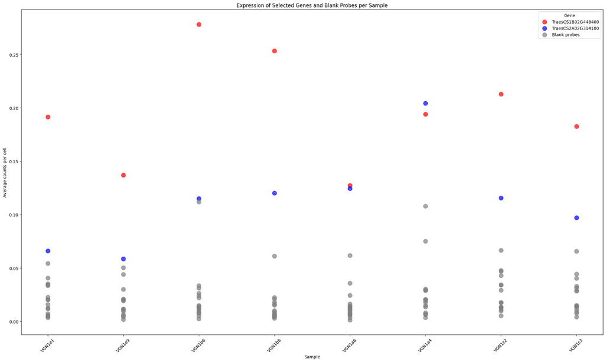

```python
# Define columns to plot
columns_to_plot = [
    'TraesCS1B02G448400', 'TraesCS2A02G314100', 'Blank-0', 'Blank-1', 'Blank-2', 'Blank-3',
    'Blank-4', 'Blank-5', 'Blank-6', 'Blank-7', 'Blank-8', 'Blank-9', 'Blank-10',
    'Blank-11', 'Blank-12', 'Blank-13', 'Blank-14'
]

# Specify the order of samples
sample_order = ['VGN1e1', 'VGN1e9', 'VGN1b6', 'VGN1b8', 'VGN1a6', 'VGN1a4', 'VGN1c2', 'VGN1c3']

# Reorder the DataFrame according to the specified sample order
plot_df = reshaped_df.loc[sample_order, columns_to_plot]

# Create the plot
plt.figure(figsize=(20, 12))

# Plot grey dots for Blank probes and add a legend entry for them
blank_plotted = False  # To ensure we only add one legend entry for 'Blank probes'
for col in columns_to_plot:
    if col.startswith("Blank"):
        color = 'grey'
        plt.scatter(plot_df.index, plot_df[col], color=color, s=100, alpha=0.7)
        if not blank_plotted:
            plt.scatter([], [], color='grey', label='Blank probes', s=100, alpha=0.7)  # Add grey dot to legend once
            blank_plotted = True
    elif col == 'TraesCS1B02G448400':
        plt.scatter(plot_df.index, plot_df[col], color='red', label='TraesCS1B02G448400', s=100, alpha=0.7)
    elif col == 'TraesCS2A02G314100':
        plt.scatter(plot_df.index, plot_df[col], color='blue', label='TraesCS2A02G314100', s=100, alpha=0.7)

# Add legend with the specified labels
plt.legend(title='Gene', loc='upper right')

# Set labels and title
plt.xlabel('Sample')
plt.ylabel('Average counts per cell')
plt.title('Expression of Selected Genes and Blank Probes per Sample')

# Adjust x-axis tick labels
plt.xticks(rotation=45)
plt.tight_layout()

plt.savefig('qc/ABD_blankprobes_avgexp_percell.svg',  dpi=700, bbox_inches='tight', format='svg', transparent=True)
# Show the plot
plt.show()
```